# Investigating the Effects of Climate Change on a Global and Local Level in Washington State

**Brady Boun, Jonah Byther, Mateo Cuadros, and Lainey Mendoza**

Department of STEM

DAT4500: Data and Society

Dr. Brian Gill

[interactive chart not shown]

# Abstract

Climate change has caused lasting and devastating ecological, economic, and health consequences to communities around the globe. To best mitigate the consequences of climate change, it is necessary to analyze multiple factors to determine how they impact global and regional climate. We tested three hypotheses to see if greenhouse gases (GHG’s), sea surface temperature, and global temperature are key variables responsible for global climate change. The first states that as sea surface temperature anomalies and radiative forcing increases, global temperature anomalies will increase. The second states that increases in Washington’s annual temperature can be explained by the year, sea surface temperature anomalies, and radiative forcing. The third states that global warming affects Washington’s summer/warmer months more than winter/colder months. To test these hypotheses, we gathered open-source climate data from the National Oceanic and Atmospheric Administration (NOAA), Copernicus Climate Change Service (C3S), and United States Environmental Protection Agency (EPA). Multiple regression analyses were run to examine how sea surface temperatures and radiative forcing affect global and local-level Washington State temperature. A simple regression was run to examine long-term warming trends for each individual county in Washington as well. The multiple regression analyses revealed that sea surface temperature and radiative forcing have a statistically significant influence on both global and local Washington State temperatures. Furthermore, simple regression analyses of Washington counties on a per-month basis revealed that summer months have notably more significant positive increases in temperature compared to non-summer months. These results suggest that radiative forcing, which is caused by greenhouse gas emissions, and rising sea surface temperatures play a key role in the warming of global and local climates.

# Introduction

Global climate change has become an increasing crisis as the world develops. Despite the attention and publicity that climate change receives, there is little consensus among the general population about what climate change truly means, let alone what climate itself truly is. Climate refers to the average weather patterns of an area over a period of 30 years. For the most part, the climate is very stable even if the regional climate has variable weather (National Geographic Society, 2025). So, global climate change is simply the change of this stable global system over time. But what’s so bad about that? Regional climates are very sensitive to changes in the global climate; any minute difference in the global climate could create more extreme weather phenomena, which can create further devastating consequences for regional climate (Lindsey & Dahlman, 2023). Due to the danger that unmonitored climate change poses to agriculture, infrastructure, ecosystem health, and more, devoted climate scientists are working hard to identify any variables that might be contributing to global climate change (NOAA, 2025). Based on preliminary research, it was determined that some of the most impactful variables that influence global climate, and therefore regional climate, are greenhouse gases (GHG’s), ocean heat, and global temperature. Using these variables, we want to understand how the global climate and the regional climate of Washington state change over time and how they impact each other.

**Greenhouse Gases**

In an age of industrialization, fossil fuels and greenhouse gases (GHGs) are continually used for economic and manufacturing activities. The emissions of greenhouse gases, such as carbon dioxide and methane, lead to changes in temperature (Mikhaylov et al., 2020). The increase in GHG concentrations as a repercussion of human activity influences the climate by causing abnormal weather patterns, changes in sea levels, and other factors of the environment (Filonchyk et al., 2024). The emissions of GHGs are harmful to the environment and lead to climate change because it intensifies the greenhouse effect. The greenhouse effect is an increase in temperature of the earth’s surface due to the heating of the lower layers of the earth’s atmosphere, which is caused by the increase in GHGs. This results in the air temperature being greater than usual, which results in irreversible impacts such as climate change and global warming (Huang et al., 2016).

The process by which GHGs warm the atmosphere can be explained by radiative forcing. Radiative forcing is the measure of how much energy from the sun enters Earth’s atmosphere compared to how much energy leaves the atmosphere (Masson-Delmotte et al., 2021; MIT, 2024). Positive radiative forcing indicates that more energy is getting trapped in the atmosphere, thus warming land surfaces (European Environment Agency, 2017). Radiative forcing is influenced by a variety of factors that absorb heat, such as GHGs and land exposed by deforestation, and reflect heat, such as clouds or polar ice (MIT, 2024).

**Ocean Heat and Temperature**

Furthermore, the cause and effect of GHGs on global warming directly impacts ocean heat levels. The increase in ocean heat and sea surface temperature are detrimental to the environment. The ocean can collect substantial amounts of heat with very little increase in temperature, which it then releases over an extended period of time through evaporation, melting ice shelves, or releasing the heat energy back into the atmosphere (Lindsey & Dahlman, 2023). A fast rate of ice shelves melting, primarily due to climate change, can cause detrimental impacts on the environment. As shown in a study on melting glaciers, the researchers discovered that glaciers are melting “with a top-notch acceleration in recent years, posing existential threats to coastal groups via expanded flooding and erosion. Freshwater resources, critical for billions of humans, are dwindling as glaciers that once fed fundamental rivers reduce” (Singh, 2025). As we know it, ocean heat is a primary driver in the safety of our land environment. As global heat rises, the hotter air will result in more heat energy being absorbed into the ocean, which will ultimately result in catastrophic impacts to the earth that may be irreversible.

One of the key roles of the ocean is to redistribute the energy that it absorbs. As the ocean absorbs more heat, the sea surface temperature increases (Environmental Protection Agency, 2024). Sea surface temperature primarily impacts the climate by altering the amount of water vapor over the oceans. Increased surface temperatures increase the moisture content at the ocean’s surface, which influences weather patterns and the severity of storms (Environmental Protection Agency, 2024). Another function of sea surface temperature, which is more relevant to this current study, is distributing heat. Heated surface water is carried by ocean currents around the globe, distributing heat to the colder regions of the planet (NOAA, 2013). Considering how much the Pacific Ocean influences Washington’s climate, this phenomenon is worth investigating. While sea surface temperature may have a more indirect effect on climate, it is still worth investigating.

**Additional Contributing Factors**

Unfortunately, climate change is an incredibly complex phenomenon with no single, definitive cause. While the previously mentioned factors may play a role in climate change, there are several other natural and anthropogenic (human-caused) factors that influence our climate. For example, natural contributors include variations in solar radiation, changes in Earth’s orbit around the sun, and tectonic activity (Nikolov & Petrov, 2014). In addition to GHG emissions, deforestation is another significant anthropogenic contributor. Harris et al. (2021) found that forests absorb approximately 7.6 billion metric tons of carbon dioxide equivalent (GtCO2eq) molecules, which is nearly 1.5 times the annual CO2 emission of the United States (4.8 GtCO2eq). However, as deforestation continues, the absorption of emissions will diminish, and the greenhouse gas effect will intensify. While these specific factors are beyond the scope of this study, they are mentioned to highlight the complexity of climate change. There is no single model or hypothesis that can fully predict climate change; there will always be some degree of uncertainty when discussing contributors to our warming climate.

**The Present Study**

The purpose of the present study is twofold: 1) examine annual changes in global temperature based on GHGs and ocean heat, and 2) examine similar trends in Washington and compare how Washington’s trends may differ from global trends. Given the extensive research conducted on climate change, several global temperature trends have already been identified. However, given the unique geography of Washington and the Pacific Northwest, local temperature trends may vary from global trends, which warrant additional analysis and explanation. To analyze global temperature change, we will be utilizing anomalies, a metric used to compare individual years to a certain baseline. To understand how global and Washington temperatures have changed over time and how these trends compare to one another, we hypothesized the following:

H1: As sea surface temperature anomalies and radiative forcing increases, global temperature anomalies will increase.

H2: Increases in Washington’s annual temperature can be explained by the year, sea surface temperature anomalies, and radiative forcing.

H3: Global warming affects Washington’s summer/warmer months more than winter/colder months.

# Methods

**Data Sources**

Global temperature anomaly data, as reported in Celsius, were collected from Our World in Data (https://cds.climate.copernicus.eu/datasets/reanalysis-era5-single-levels-monthly-means?tab=overview). Two separate data sets were downloaded; one containing each country’s average annual temperature anomalies and the other containing each country’s average monthly temperature anomalies. Temperature anomaly is defined as the difference between that year or month’s average surface temperature and the mean temperature from 1991-2020 in Celsius. The data were sourced from “Copernicus Climate Change Service information – ERA5 monthly averaged data on single levels from 1940 to present.” ERA5 refers to the fifth-generation reanalysis for the European Centre for Medium-Range Weather Forecasts (ECMWF). Reanalysis refers to the combination of new weather observations with the previously completed estimate. The reanalysis integrates “model data with observations from across the world into a globally complete and consistent dataset,” based along the principles of data assimilation, however at a reduced state to allow for a dataset spanning back decades. ERA5 provides hourly estimates for atmospheric, ocean-wave, and land-surface values. The reanalysis is updated daily, but a final release is not released until 2 to 3 months later. Because of this, the final released data could differ from the ERA5 update daily data.

Washington temperature data were acquired from two separate sources. First, county level temperature data were downloaded from the Global Historical Climatology Network daily (GHCNd) database, located on the National Oceanic and Atmospheric Administration’s (NOAA) website (https://www.ncei.noaa.gov/products/land-based-station/global-historical-climatology-network-daily). The GHCNd database compiles daily climate summaries recorded by land-surface stations across the United States, measuring variables such as temperature, precipitation, and wind speed. For the scope of our analysis, only the average temperature was selected. The data for each station is contained in a separate CSV file, so creating a complete data set for all of Washington’s counties required downloading individual data sets for each county and joining them together. For each county, the station with the most years on record and most coverage was downloaded. Of course, there are possible ramifications to only choosing one station per county, like losing data that could reveal local temperature patterns over time in different states. This was chosen due to needing to minimize the data set size while maximizing the data coverage.

Monthly temperature for the entirety of Washington state was collected from NOAA’s Climate at a Glance Time Series database (https://www.ncei.noaa.gov/access/monitoring/climate-at-a-glance/statewide/time-series/45/tavg/1/0/1970-2024). While average state temperatures could have been calculated from the county-level data, producing an accurate temperature would require weighting each county’s data individually, which is beyond the scope of our knowledge or skills. Instead, we opted to use data already weighted by a reputable source. The dataset itself is quite simple; one column contains the date of measurement (a combination of the year and month) and the other contains the average temperature for that date. NOAA got the statewide Washington data from the U.S. Climate Divisional Database, a database that has been recording the climate of each state since 1895. Each state is split into different climate divisions, with Washington having ten separate divisions. For each of the ten divisions, monthly state temperature was calculated by averaging the daily observations of multiple weather stations. Each division’s monthly value is then averaged and weighted by area to produce a statewide monthly temperature. The data should be representative of Washington’s average temperature, provided that NOAA’s calculations and weighting process reflect the true nature of Washington’s weather patterns.

To measure the concentration of greenhouse gases in the atmosphere, we downloaded data from NOAA’s Annual Greenhouse Gas Index (AGGI) project (https://gml.noaa.gov/aggi/aggi.html). The data provides: 1) annual global radiative forcing values for gases such as carbon dioxide, methane, and nitrous oxide, 2) the total global radiative forcing of all gases combined, 3) the current concentration of greenhouse gases in the atmosphere, 4) an AGGI value, and 5) the percent change from one year to the next. Out of these variables, we focused on the total annual global radiative forcing and greenhouse gas concentration variables. NOAA uses the Intergovernmental Panel on Climate Change’s formula (which is very complex) to calculate annual global radiative forcing, which is measured in watts per square meter. Atmospheric greenhouse gas concentrations are measured in carbon dioxide equivalent parts per million (PPM), providing a simple metric for understanding the molecular makeup of the atmosphere. Air samples were collected from 80 different background air sites across the globe, which are part of NOAA’s Global Greenhouse Gas Network. Weekly data were used from each site to calculate annual average metrics. Given that numerous air samples from around the world were collected, these data are representative of the entire atmosphere.

Data for sea surface temperatures were downloaded from the United States Environmental Protection Agency website (https://www.epa.gov/climate-indicators/climate-change-indicators-sea-surface-temperature). The sea surface temperature data measures annual temperature anomalies compared to the average baseline temperature from 1971-2000. The dataset itself contains the year, the annual temperature anomaly (measured in Fahrenheit), the lower 95% confidence interval, and the upper 95% confidence interval. Data was measured systematically using ships, stationary buoys, and drifting buoys. NOAA carefully reconstructed and filtered the data to reduce any biases introduced by different sampling methods and to account for locational differences. Overall, the data is representative of the average sea surface temperature around the world.

**Data Manipulation**

To create a unified dataset for Washington counties, individual datasets for each county were downloaded from NOAA Climate Data Online. These datasets were hand-picked while considering the coverage of the county’s weather station and the number of years it covers. All the small datasets were combined into one large dataset using the rbind() command from R-Studio. The datasets didn’t have a counties column, so code was used to manually add a county to each station using if-else statements.

To create a single dataset for running statistical analyses, we took each relevant dataset (namely the AGGI, ocean heat content, sea surface temperature, Washington monthly temperature, and global temperature anomaly datasets) and planned to join the data by each dataset’s year variable. The process of combining the data was simple, as every dataset except for the Washington monthly temperature set was already formatted to display each year as a separate row. To properly format the Washington monthly temperature data, we split the date column into two separate columns: one for the year and one for the month. We then computed a new variable for the annual average temperature by grouping the data by year and averaging each month’s temperature together. The data was then ungrouped and ready to be joined. Each dataset was then joined by year. Given that each dataset recorded data across different year ranges, the combined dataset only has the years that were recorded across all datasets. This resulted in a final year range between 1979 and 2023.

To incorporate the temperature anomaly, Washington temperature, Washington county, ocean, and greenhouse gas datasets together, a shiny dashboard was created. The dashboard, located at the beginning of this report, includes all the visualizations covered in this report. The dashboard also includes additional interactive visualizations using the same data that fall outside this study’s scope.

**Statistical Methods**

Simple linear regression was used to examine the relationship between the year and the average temperature for each Washington county. Linear regression was used on a line graph with Year on the x-axis and Average Temperature on the y-axis. This method was used because it allows us to easily see the overall trend of average temperature across the years. While simple linear regression is typically used to create the best predictive model of data and prioritizes a high R<sup>2</sup> value, we used it to identify significant relationships between each county’s temperature and a particular month. As such, we are more concerned about the p value for each individual relationship instead of the overall model fit. This will allow us to see the overall trend average temperature over the years and if the linear regression line is positive or negative. However, it’s hard to determine by eye whether a regression line on the line graph is significant or not, so a table was created to place each regression line into its respective category.

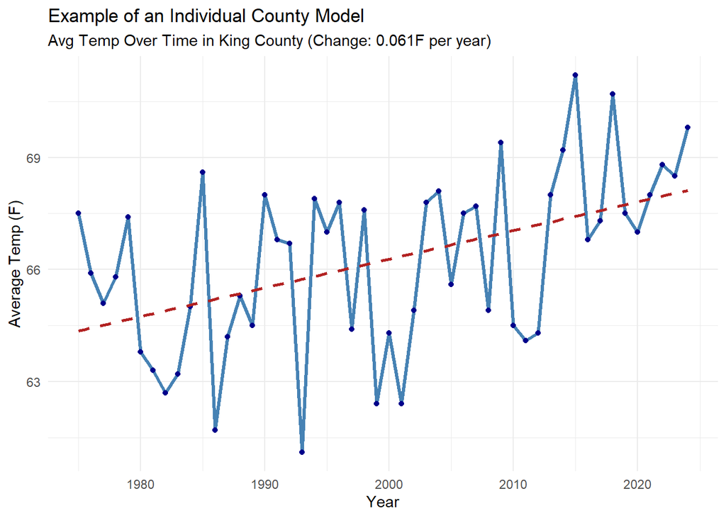

Multiple regression was used to examine the relationship between our independent variables (year, radiative forcing, and sea surface temperature anomaly) and our dependent variables (global temperature anomalies and Washington’s annual temperature). Multiple regression was used because climate change is simultaneously impacted by many factors; looking at a single predictor would not be the best fit, as multiple forces are present in climate change. One of the key assumptions of multiple regression that must be fulfilled to produce valid results is that there is no multicollinearity. Multicollinearity occurs when two or more of the independent variables are highly correlated with one another and introduces redundancy (multiple variables measuring the same thing) into the model, which can bias the results. Given that radiative forcing and sea surface temperature have been steadily increasing over time, multicollinearity is bound to occur.

To prevent multicollinearity, we used principal component analysis (PCA). PCA transforms a dataset with a large number of variables, which are often highly correlated to each other, into a smaller dataset with fewer variables but a similar amount of information (Jaadi & Whitfield, 2024). PCA follows five steps: 1) normalize the data to ensure accurate comparisons, 2) calculate variable correlations for each pair of variables, 3) use eigenvalues and eigenvectors to calculate each principle component, 4) rank each principle component based on the amount of variance in the data it explains, and 5) reorganize the data to fit the new principle components (Jaadi & Whitfield, 2024; Kelta, 2023). In other words, PCA takes the data and reorganizes it into new variables (called principal components) that are completely independent from one another. When working with large datasets (e.g. more than ten variables), this process allows for all the data to be expressed in two to three variables, greatly simplifying analyses. For our study, PCA is being used to eliminate multicollinearity and produce completely independent variables to represent our original predictor variables.

# Results

**Multiple Regression Temperature Analyses**

To test for multicollinearity between year, sea surface temperature, and radiative forcing, we computed a correlation matrix and observed the following relationships: year and sea surface temperature were highly positively correlated, *r(43)* = .90, *p* < .001. Year and radiative forcing were highly positively correlated, *r(43)* = 1.00, *p* < .001. Finally, sea surface temperature and radiative forcing were highly positively correlated, *r(43)* = .90, *p* < .001. Given the extreme correlation between these variables, we used principal component analysis to create new independent predictor variables.

```
##
##
## Means, standard deviations, and correlations with confidence intervals
##
##
##   Variable                    M       SD    1            2
##   1. Year                     2001.00 13.13
##
##   2. Sea_Surface_Temp_Anomaly 0.35    0.31  .90**
##                                             [.82, .94]
##
##   3. Total_Rad_Force          2.65    0.48  1.00**       .90**
##                                             [1.00, 1.00] [.82, .94]
##
##
## Note. M and SD are used to represent mean and standard deviation, respectively.
## Values in square brackets indicate the 95% confidence interval.
## The confidence interval is a plausible range of population correlations
## that could have caused the sample correlation (Cumming, 2014).
##  * indicates p < .05. ** indicates p < .01.
##
```

The principal component analysis produced three factors which explain 100% of the variation in the correlation matrix. *Component 1* (95.4% of variance) was loaded by the year (Year = .58), sea surface temperature (Sea_Surface_Temp_Anomaly = .56), and radiative forcing (Total_Rad_Force = .58). *Component 2* (4.6% of variance) was loaded by the year (Year = .40), sea surface temperature (Sea_Surface_Temp_Anomaly = -.83), and radiative forcing (Total_Rad_Force = .40). *Component 3* (0.04% of variance) was loaded by the year (Year = .71) and radiative forcing (Total_Rad_Force = -.71).

```
##                             Comp.1     Comp.2       Comp.3
## Year                     0.5845448  0.3961524  0.708075327
## Sea_Surface_Temp_Anomaly 0.5628067 -0.8265857 -0.002163352
## Total_Rad_Force          0.5844279  0.3997741 -0.706133593
```

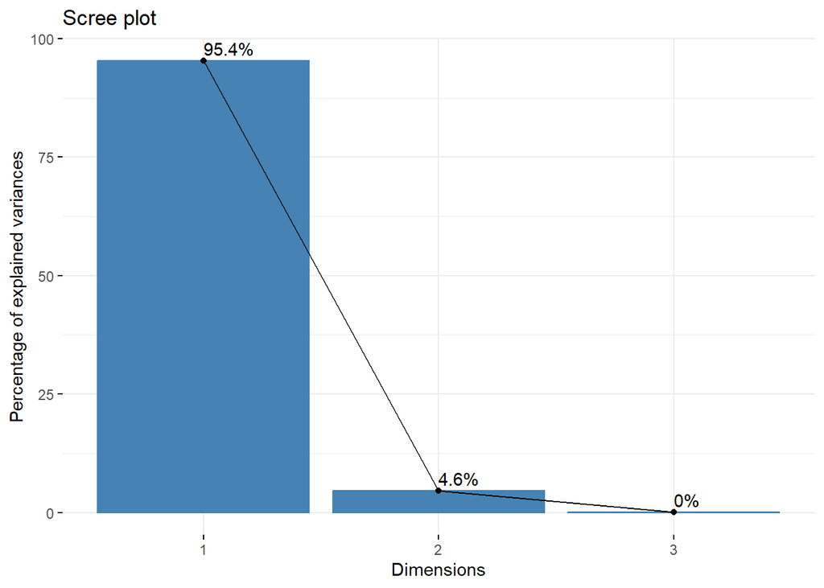

Using these three new factors, we used multiple regression to test H1. This yielded a statistically significant model, *F(3, 41)* = 337.8, *p* < .001, *R<sup>2</sup>* = .96, *adjusted R<sup>2</sup>* = .96. The individual independent variables were investigated further, indicating that component 1 (*t* = 31.08, *p* < .001) and component 2 (*t* = -6.88, *p* < .001) were statistically significant, while component 3 (*t* = .25, *p* = .81) is not significant.

```
##
## Call:
## lm(formula = Temperature_anomaly ~ pca_global$scores, data = joined_global_data)
##
## Residuals:
##       Min        1Q    Median        3Q       Max
## -0.102839 -0.038960 -0.005423  0.035039  0.145471
##
## Coefficients:
##                          Estimate Std. Error t value Pr(>|t|)
## (Intercept)             -0.066759   0.008617  -7.747 1.48e-09 ***
## pca_global$scoresComp.1  0.160105   0.005151  31.081  < 2e-16 ***
## pca_global$scoresComp.2 -0.162074   0.023561  -6.879 2.44e-08 ***
## pca_global$scoresComp.3  0.061130   0.248019   0.246    0.807
## ---
## Signif. codes:  0 '***' 0.001 '**' 0.01 '*' 0.05 '.' 0.1 ' ' 1
##
## Residual standard error: 0.05781 on 41 degrees of freedom
## Multiple R-squared:  0.9611, Adjusted R-squared:  0.9583
## F-statistic: 337.8 on 3 and 41 DF,  p-value: < 2.2e-16
```

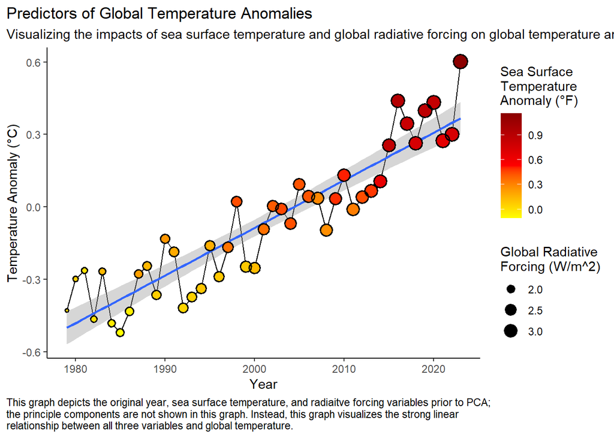

Multiple regression was then used to test H2, which resulted in a significant model, *F(3, 41)* = 8.81, *p* < .001, *R<sup>2</sup>* = .39, *adjusted R<sup>2</sup>* = .35. The individual predictors were examined further, indicating that the component 1 (*t* = 3.74, *p* < .001), and component 2 (*t* = -2.95, *p* = .005) were statistically significant, but component 3 (*t* = -1.92, *p* = .06) was not.

```
##
## Call:
## lm(formula = Temp ~ data.pca$scores, data = cleaned_wa_pca)
##
## Residuals:
##      Min       1Q   Median       3Q      Max
## -2.13958 -0.60653 -0.04088  0.66509  1.85498
##
## Coefficients:
##                       Estimate Std. Error t value Pr(>|t|)
## (Intercept)           47.11444    0.13506 348.837  < 2e-16 ***
## data.pca$scoresComp.1  0.30219    0.08074   3.743 0.000559 ***
## data.pca$scoresComp.2 -1.09102    0.36929  -2.954 0.005170 **
## data.pca$scoresComp.3 -7.47005    3.88736  -1.922 0.061623 .
## ---
## Signif. codes:  0 '***' 0.001 '**' 0.01 '*' 0.05 '.' 0.1 ' ' 1
##
## Residual standard error: 0.906 on 41 degrees of freedom
## Multiple R-squared:  0.392,  Adjusted R-squared:  0.3475
## F-statistic:  8.81 on 3 and 41 DF,  p-value: 0.0001254
```

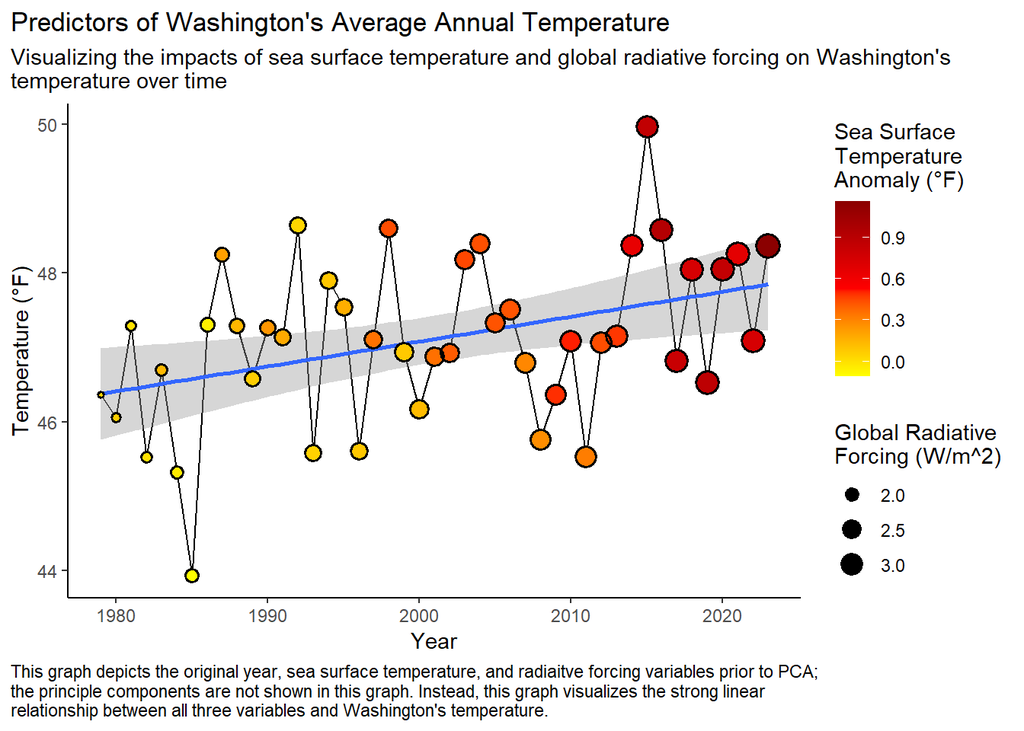

**Washington County-Level Temperature Regression**

Linear regression was used to test H3 by evaluating the average monthly temperature across the years 1975 to 2024 for each county. Individual regression models were created for each pairing of county and month to evaluate the statistical significance of the relationship between the given month and the county’s average temperature (for example, one model may examine July-specific temperature for King County using the year to predict the average temperature). A table was created containing the count of significant positive regression lines, significant negative regression lines, and insignificant regression lines.

```
##     X      Month Sig_Counties Positive_Slope Negative_Slope Not_Significant
## 1   1 All Months            2              2              0              35
## 2   2    January           10             10              0              27
## 3   3   February            1              0              1              36
## 4   4      March            0              0              0              37
## 5   5      April            3              1              2              34
## 6   6        May           14             14              0              23
## 7   7       June            8              8              0              29
## 8   8       July           32             32              0               5
## 9   9     August           26             26              0              11
## 10 10  September           17             17              0              20
## 11 11    October            3              3              0              34
## 12 12   November            1              1              0              36
## 13 13   December            0              0              0              37
```

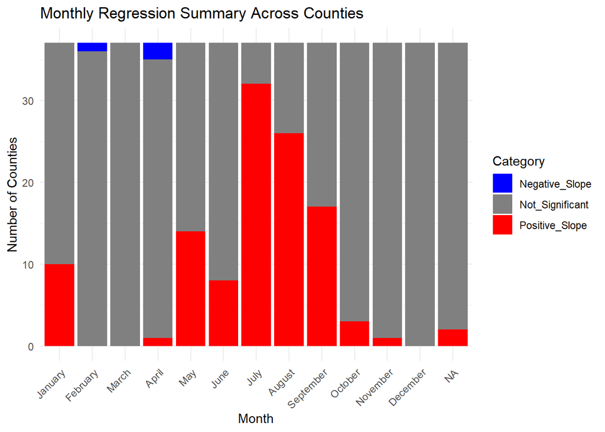

# Discussion

Several significant warming trends have been identified in the global climate and Washington’s climate. Through a combination of PCA and multiple regression, we found that the year, sea surface temperatures, and radiative forcing have a significant influence on global and Washington temperatures, validating H1 and H2. Additionally, examining each county’s regression line per month revealed that summer months have notably more significant positive regression lines compared to non-summer months, validating H3.

**Global Anomalies and Washington’s Annual Temperature**

While year, sea surface temperature, and radiative forcing were the initial predictors of the global and Washington temperatures, we couldn’t use these exact variables in a multiple regression because of their multicollinearity. By using PCA, we combined the effects of each predictor to create new principal component variables, which made the interpretation of each model less straightforward. Since both models used the same predictors prior to PCA, they will also use the same post-PCA predictors. To understand what each model is communicating, we must synthesize each principal component’s factor loadings with its corresponding regression coefficients.

For component 1, the year (*loading* = .58), sea surface temperature (*loading* = .56), and radiative forcing (*loading* = .58) variables were given similar loadings. meaning that each variable’s impact on the first component was roughly the same and each variable moves together at a similar rate. In essence, component 1 takes the individual effects of each variable and averages them together. In both models, component 1 has a positive regression coefficient. This means that as year, sea surface temperature, and radiative forcing increase together at a steady rate, temperature will increase.

For component 2, the year (*loading* = .40) and radiative forcing (*loading* = .40) variables have the same loadings, suggesting that this component captures when these two variables move together at a similar rate. However, sea surface temperature (*loading* = -.83) has a substantially larger negative loading, indicating that this component captures whenever sea surface temperature follows a different pattern than the steady increase observed in component 1. Component 2 has a negative coefficient in both models, which suggests that if the year and radiative force increase consistently, but the sea surface temperature is colder than expected, temperature will decrease. In other words, component 2 represents an adjustment to the prediction of component 1; if the sea surface temperature is increasing, but it is not increasing at the rate that component 1 predicts, the component will slightly adjust the temperature prediction downward.

Finally, component 3 only uses the year (*loading* = .71) and radiative forcing (*loading* = -.71) variables, whose loadings have the same magnitude but opposite signs. Based on the interpretation of component 2, this suggests that component 3 exerts its effect whenever radiative forcing is lower than expected. Component 3 is the only predictor to have different effects on each model, but it is also the only non-statistically significant predictor. Despite the lack of significance, it is still helpful to understand what this component means in the context of both models. For the global temperature anomaly model, when radiative forcing is lower than anticipated, an upward adjustment is made to the temperature prediction (which seems counterintuitive). For the Washington temperature model, lower levels of radiative forcing result in a downward adjustment to the temperature prediction.

Furthermore, the dissimilarity between models may also be caused by the local climate variability in Washington. Washington has many different dramatic seasonal temperature patterns, going from cold to hot very quickly. However, global anomalies consider a much broader climate, taking into account all the temperatures around the globe. Additionally, local temperatures are “noisier.” Washington has microclimates, making it difficult to isolate climate drivers. Microclimates are “climate conditions at a ‘microscale’ on the earth’s underlying surface” (Yang et al., 2023). To elaborate, Washington has many microclimates (i.e., forests, urban heat islands, etc.), which create fluctuations in the state’s average temperature. These natural fluctuations will create more variation in the model, as depicted by the lower *R<sup>2</sup>*. While Washington’s temperatures may be subject to more variation, they still follow global climate trends to a certain degree. In other words, significant warming of the global climate will warm Washington’s climate, regardless of the additional factors that influence Washington’s temperature.

**Washington’s County-Level Temperature Trends**

**Implications for the Future**

Our results have shown that the radiative forcing caused by greenhouse gas emissions and rising sea surface temperatures play a key role in the warming of global and local climates. Considering how much of an impact these factors have on global temperatures, something must be done. If greenhouse gas emissions remain unchecked, more heat will get trapped in the atmosphere and absorbed by the oceans, both of which will increase the temperature of our planet. This is a global issue. While some local climates may be less impacted by climate change than others, all local climates follow the same overall trend as the global climate; if the global climate is warming, all other climates will eventually follow suit. Given that our global climate has shifted so dramatically, one may wonder if it is possible to reverse the effects of climate change. While the answer to this question remains unclear, we do know that it is possible to mitigate future warming.

One of the easiest solutions to focus on is reducing global greenhouse gas emissions. Given the high correlation between radiative forcing and sea surface temperature, reducing one variable would cause a reduction in the other. Considering that we have more control over the amount of anthropogenic greenhouse emissions than the natural distribution of heat through ocean currents, focusing on gas emissions seems far more practical. There are several ways in which humans are already trying to reduce gas emissions, such as moving away from fossil fuels in favor of cleaner and renewable energy sources, creating sustainable infrastructure, strengthening forests, and enacting policies that limit and reduce gas emissions (Turrentine, 2022). It is important to remember that climate change cannot be caused or fixed by one singular group or political entity. While it is easier for changes to occur at a local level, it is not the local changes that produce a significant reduction in gas emissions. For instance, even if the state of Washington were to cut its emissions to zero, this reduction could not combat the steadily increasing gas emissions produced by other states or countries. Therefore, despite what sustainable changes we make at a global level, we will only see significant mitigation of global climate change if all countries come together and focus on reducing their emissions. While global collaborative efforts have been attempted in the past, we have yet to see a satisfactory level of cooperation

On a lasting note, it is important to recognize that “green” products may not be as beneficial to climate change as we think. One example is electric vehicles, where their impact on climate change depends heavily on the energy mix used to generate the power for the vehicle (Holdway, 2010). In addition, these vehicles’ production cycle may emit GHGs into the atmosphere that offset the overall benefits of EVs. Furthermore, these products may lead to unintended incentives that lead to increased pollution. In the instances of hybrids and EVs, it may encourage individuals to drive more because of the higher mileage or lower operating costs (referring to electricity consumption for EVs). Keeping in mind these nuances, “green” or “carbon neutral” products can only be truly effective if implemented thoughtfully and when consumers remain conscious of their broader impact on the planet.

**Limitations**

The first limitation of our research includes the exclusion of other variables that affect climate change. Although we tested variables that directly translate to climate change (GHGs, radiative forcing, time), we did not consider another major climate change contributor, deforestation. It is important to note that this is a crucial component because deforestation results in less GHG emissions being absorbed (Harris et al., 2021). Also, another variable we did not consider is the melting of glaciers. The acceleration of glaciers melting causes environmental habit destruction and reduces freshwater resources from flooding and erosion (Singh, 2025).

Second, when looking specifically at our Washington county data, it is difficult to understand the entire scope of Washington State because of the difficulties with data compiling. We only used one station per county, which increases the amount of variance involved since we did not use every station’s data within each county. Finally, the use of PCA produced new predictor variables with no clear, objective interpretation. While we did our best to interpret and assign meaning to these predictors using their factor loadings and corresponding regression coefficients, there is no way to guarantee that we have provided a fully accurate interpretation. Our interpretations are subjective, meaning they may not capture the true relationship that each component represents.

# Works Cited

Althor, G., Watson, J. E., & Fuller, R. A. (2016). Global mismatch between greenhouse gas emissions and the burden of climate change. *Scientific reports, 6*(1), 20281.

Environmental Protection Agency. (2024). *Climate Change Indicators: Sea Surface Temperature.* https://www.epa.gov/climate-indicators/climate-change-indicators-sea-surface-temperature

European Environment Agency. (2017). *Radiative Forcing.* https://www.eea.europa.eu/help/glossary/eea-glossary/radiative-forcing#.

Filonchyk, M., Peterson, M. P., Zhang, L., Hurynovich, V., & He, Y. (2024). Greenhouse gases emissions and global climate change: Examining the influence of CO2, CH4, and N2O. *Science of The Total Environment*, 173359.

Harris, N. L., Gibbs, D. A., Baccini, A., Birdsey, R. A., De Bruin, S., Farina, M., … & Tyukavina, A. (2021). Global maps of twenty-first century forest carbon fluxes. *Nature Climate Change, 11*(3), 234-240.

Hersbach, H., Bell, B., Berrisford, P., Biavati, G., Horányi, A., Muñoz Sabater, J., … & Thépaut, J. N. (2023). ERA5 monthly averaged data on pressure levels from 1940 to present. Copernicus Climate Change Service (C3S) Climate Data Store (CDS), 10.

Holdway, A. R., Williams, A. R., Inderwildi, O. R., & King, D. A. (2010). Indirect emissions from electric vehicles: emissions from electricity generation. *Energy & Environmental Science, 3*(12), 1825-1832.

Huang, S. K., Kuo, L., & Chou, K. L. (2016). The applicability of marginal abatement cost approach: A comprehensive review. *Journal of Cleaner Production, 127*, 59-71.

Jaadi, Z., & Whitfield, B. (2024, February 23). Principal component analysis (PCA): A step-by-step explanation. *Built In.* https://builtin.com/data-science/step-step-explanation-principal-component-analysis#.

Kelta, Z. (2023, February 13). Principal component analysis in R tutorial. *Data Camp*. https://www.datacamp.com/tutorial/pca-analysis-r.

Lindsey, R. (2009, January 14). *Climate and Earth’s Energy Budget*. NASA. https://earthobservatory.nasa.gov/features/EnergyBalance#.

Lindsey, R., & Dahlman, L. (2023, September 6). *Climate change: Ocean heat content*. NOAA Climate.gov. https://www.climate.gov/news-features/understanding-climate/climate-change-ocean-heat-content.

Masson-Delmotte, V., Zhai, P., Pirani, A., Connors, S. L., Péan, C., Berger, S., … & Zhou, B. (2021). Climate change 2021: the physical science basis. Contribution of working group I to the sixth assessment report of the intergovernmental panel on climate change, *2*(1), 2391.

Mikhaylov, A., Moiseev, N., Aleshin, K., & Burkhardt, T. (2020). Global climate change and greenhouse effect. *Entrepreneurship and Sustainability Issues, 7*(4), 2897.

MIT. (2024). *Explainer: Radiative Forcing.* Climate Portal. https://climate.mit.edu/explainers/radiative-forcing#.

National Oceanic and Atmospheric Administration. (2024, January 2). The Transfer of Heat Energy. https://www.noaa.gov/jetstream/atmosphere/transfer-of-heat-energy.

Nikolov, T., & Petrov, N. (2014). Main factors influencing climate change: A review. *Comptes Rendus de l’Académie Bulgare des Sciences, 67*(11), 1455-1476.

NOAA. (2013). *How does the ocean affect climate and weather on land?* NOAA Ocean Exploration. https://oceanexplorer.noaa.gov/facts/climate.html#.

Singh, J. (2025). The accelerating melting of glaciers: Impacts on earth and emerging challenges. *International Journal of Advanced Research and Interdisciplinary Scientific Endeavours, 2*(1), 401-414.

Trumbore, S., Brando, P., & Hartmann, H. (2015). Forest health and global change. *Science, 349*(6250), 814-818.

Turrentine, J. (2022, December 13). What Are the Solutions to Climate Change? *NRDC.* https://www.nrdc.org/stories/what-are-solutions-climate-change

[output not shown]